# Log2 fold changes of NMD and no-NMD ORFs

Roberto Albanese

17/02/2023

## Attaching the needed R packages

```r
# Attaching the packages
suppressMessages(library("rtracklayer"))
suppressMessages(library("GenomicFeatures"))
suppressMessages(library("GenomicRanges"))
suppressMessages(library("GenomicAlignments"))
suppressMessages(library("ggplot2"))
suppressMessages(library("ggpubr"))
suppressMessages(library("dplyr"))
suppressMessages(library("ORFquant"))
suppressMessages(library("readxl"))
suppressMessages(library("viridis"))
```

## Loading objects and obtaining paths of the BAM files

The GENCODE v25 annotation object as well as the extended end coordinates of ORFs are loaded. Then, paths of the Ribo-seq and RNA-seq BAM files are obtained and stored.

```r
# Loading the GENCODE v25 annotation object
load_annotation("/group/calviello/Lorenzo/Annotation/human/RiboseQC/gencode.v25.annotation.gtf.gz_Rannot")
# Loading the extended end coordinates
extcoords_mosttr <- get(load("/group/calviello/Roberto/Suja_plots/extcoords_mosttr.RData"))
# Getting paths of Ribo-seq BAM files
ribobamfiles <- list.files(path="/group/calviello/Lorenzo/data/Suja/Suja_Bams", pattern="Ribo.*bam$", full.names = T, recursive=T)
# Getting paths of RNA-seq BAM files
rnabamfiles <- list.files(path="/group/calviello/Lorenzo/data/Suja/Suja_Bams", pattern="RNA.*bam$", full.names = T, recursive=T)
```

## Ribo-seq data

### Computing CPM values

In this part of the script a matrix with Ribo-seq CPMs is obtained. To compute CPMs, pseudocounts are divided by library size and multiplied by 1 million.

Pseudocounts are obtained by adding 1 to all raw counts. This is done in order to avoid the presence of non-finite values after log-transformation later in the analysis. Library size of a specific sample is defined as the total number of Ribo-seq reads on exons in that sample.

```r
# Getting a matrix with Ribo-seq counts on the extended end coordinates in the samples
getCoverageOnExtCoords <- function(bam){return(as.vector(assay(summarizeOverlaps(reads=bam,
                                                                                 features=extcoords_mosttr,
                                                                                 ignore.strand=FALSE,
                                                                                 mode="Union",
                                                                                 inter.feature=FALSE))))}
ribo_counts_mat <- sapply(ribobamfiles, getCoverageOnExtCoords)
colnames(ribo_counts_mat) <- c("rep1_00h", "rep2_00h", "rep3_00h",
                               "rep1_04h", "rep2_04h", "rep3_04h",
                               "rep1_08h", "rep2_08h", "rep3_08h",
                               "rep1_14h", "rep2_14h", "rep3_14h")

# Getting a vector with library sizes (read counts on exons in the different samples)
getCoverageOnexons <- function(bam){return(as.vector(assay(summarizeOverlaps(reads=bam,
                                                                            features=GTF_annotation$exons_txs,
                                                                            ignore.strand=FALSE,
                                                                            mode="Union",
                                                                            inter.feature=FALSE))))}
library_sizes <- colSums(sapply(ribobamfiles, getCoverageOnexons))
names(library_sizes) <- colnames(ribo_counts_mat)

# Dividing each column of a matrix with pseudocounts (1 was added to all raw counts) by the corresponding library size
ribo_counts_divided_mat <- sweep(ribo_counts_mat+1,2,library_sizes,FUN="/")
# Multiplying the matrix by 1 million to get CPMs
ribo_CPMs_mat <- ribo_counts_divided_mat*1e+06
```

### Computing average CPM values and log2 fold changes

In this part of the script average CPM values of each time point are computed first for no-NMD ORFs, then for NMD ORFs. Then, log2 fold changes are computed.

```r
# Function to get average CPM of a specific time point in a specific group of extended end coordinates ("NMD" or "noNMD")
getAveragesForTimePointRibo <- function(time_point = "00h", type="NMD"){
  if (time_point=="00h") {
    indx <- 1:3
  } else if (time_point=="04h") {
    indx <- 4:6
  } else if (time_point=="08h") {
    indx <- 7:9
  } else if (time_point=="14h") {
    indx <- 10:12
  }

  n <- nrow(ribo_CPMs_mat)
  if (type=="NMD") {
    avgs <- rowMeans(ribo_CPMs_mat[,indx])[((n/2)+1):n]

  } else {
    avgs <- rowMeans(ribo_CPMs_mat[,indx])[1:(n/2)]
  }

  return(avgs)
}

# Average CPMs of all the time points (no NMD)
avgs_00h_noNMD <- getAveragesForTimePointRibo(time_point = "00h", type="noNMD")
avgs_04h_noNMD <- getAveragesForTimePointRibo(time_point = "04h", type="noNMD")
avgs_08h_noNMD <- getAveragesForTimePointRibo(time_point = "08h", type="noNMD")
avgs_14h_noNMD <- getAveragesForTimePointRibo(time_point = "14h", type="noNMD")

# Average CPMs of all the time points (NMD)
avgs_00h_NMD <- getAveragesForTimePointRibo(time_point = "00h", type="NMD")
avgs_04h_NMD <- getAveragesForTimePointRibo(time_point = "04h", type="NMD")
avgs_08h_NMD <- getAveragesForTimePointRibo(time_point = "08h", type="NMD")
avgs_14h_NMD <- getAveragesForTimePointRibo(time_point = "14h", type="NMD")

# Log2 fold changes (04h vs 00h)
log2FC_04h_NMD <- log2(avgs_04h_NMD)-log2(avgs_00h_NMD)
log2FC_04h_noNMD <-log2(avgs_04h_noNMD)-log2(avgs_00h_noNMD)

# Log2 fold changes (08h vs 00h)
log2FC_08h_NMD <- log2(avgs_08h_NMD)-log2(avgs_00h_NMD)
log2FC_08h_noNMD <- log2(avgs_08h_noNMD)-log2(avgs_00h_noNMD)

# Log2 fold changes (14h vs 00h)
log2FC_14h_NMD <-log2(avgs_14h_NMD)-log2(avgs_00h_NMD)
log2FC_14h_noNMD <- log2(avgs_14h_noNMD)-log2(avgs_00h_noNMD)
```

### Obtaining dataframe with Ribo-seq results

This part of the script creates a dataframe with Ribo-seq results, i.e., log2FCs as well as the corresponding region types and time points.

```r
# Log2 fold changes
log2FCs <- c(log2FC_04h_NMD, log2FC_04h_noNMD,
             log2FC_08h_NMD, log2FC_08h_noNMD,
             log2FC_14h_NMD, log2FC_14h_noNMD)
# Region types ('NMD' or 'No NMD')
reg_type <- c(rep("NMD", length(log2FC_04h_NMD)), rep("No NMD", length(log2FC_04h_noNMD)),
              rep("NMD", length(log2FC_08h_NMD)), rep("No NMD", length(log2FC_08h_noNMD)),
              rep("NMD", length(log2FC_14h_NMD)), rep("No NMD", length(log2FC_14h_noNMD)))
# Time points
time_point <- c(rep("04h", length(c(log2FC_04h_NMD, log2FC_04h_noNMD))),
                rep("08h", length(c(log2FC_08h_NMD, log2FC_08h_noNMD))),
                rep("14h", length(c(log2FC_14h_NMD, log2FC_14h_noNMD))))

# Getting dataframe
ribo_plot_df <- data.frame(log2FCs=log2FCs,
                           type=reg_type,
                           time=time_point)
```

## RNA-seq data

### Computing CPM values

In this part of the script a matrix with RNA-seq CPMs is obtained. To compute CPMs, pseudocounts are divided by library size and multiplied by 1 million.

Pseudocounts are obtained by adding 1 to all raw counts. This is done in order to avoid the presence of non-finite values after log-transformation later in the analysis. Library size of a specific sample is defined as the total number of RNA-seq reads on exons in that sample.

```r
# Getting a matrix with RNA-seq counts on the extended end coordinates in the samples
getCoverageOnExtCoords <- function(bam){return(as.vector(assay(summarizeOverlaps(reads=bam,
                                                                                 features=(extcoords_mosttr),
                                                                                 ignore.strand=FALSE,
                                                                                 mode="Union",
                                                                                 inter.feature=FALSE))))}
rna_counts_mat <- sapply(rnabamfiles, getCoverageOnExtCoords)
colnames(rna_counts_mat) <- c("rep1_04h", "rep2_04h", "rep3_04h",
                              "rep1_08h", "rep2_08h", "rep3_08h",
                              "rep1_00h", "rep2_00h", "rep3_00h",
                              "rep1_14h", "rep2_14h", "rep3_14h")

# Getting a vector with library sizes (read counts on exons in the different samples)
getCoverageOnexons <- function(bam){return(as.vector(assay(summarizeOverlaps(reads=bam,
                                                                            features=(GTF_annotation$exons_txs),
                                                                            ignore.strand=FALSE,
                                                                            mode="Union",
                                                                            inter.feature=FALSE))))}
library_sizes <- colSums(sapply(rnabamfiles, getCoverageOnexons))
names(library_sizes) <- colnames(rna_counts_mat)

# Dividing each column of the matrix with raw counts by the corresponding library size
rna_counts_divided_mat <- sweep(rna_counts_mat+1,2,library_sizes,FUN="/")
# Multiplying the matrix by 1 million to get CPMs
rna_CPMs_mat <- rna_counts_divided_mat*1e+06
```

### Computing average CPM values and log2 fold changes

In this part of the script average CPM values of each time point are computed first for no-NMD ORFs, then for NMD ORFs. Then, log2 fold changes are computed.

```r
# Function to get average CPM of a specific time point
# in a specific group of extended end coordinates ("NMD" or "noNMD")
getAveragesForTimePointRNA <- function(time_point = "00h", type="NMD"){
  if (time_point=="00h") {
    indx <- 7:9
  } else if (time_point=="04h") {
    indx <- 1:3
  } else if (time_point=="08h") {
    indx <- 4:6
  } else if (time_point=="14h") {
    indx <- 10:12
  }

  n <- nrow(rna_CPMs_mat)
  if (type=="NMD") {
    avgs <- rowMeans(rna_CPMs_mat[,indx])[((n/2)+1):n]
  } else {
    avgs <- rowMeans(rna_CPMs_mat[,indx])[1:(n/2)]
  }

  return(avgs)
}

# Average CPMs of all the time points (no NMD)
avgs_00h_noNMD <- getAveragesForTimePointRNA(time_point = "00h", type="noNMD")
avgs_04h_noNMD <- getAveragesForTimePointRNA(time_point = "04h", type="noNMD")
avgs_08h_noNMD <- getAveragesForTimePointRNA(time_point = "08h", type="noNMD")
avgs_14h_noNMD <- getAveragesForTimePointRNA(time_point = "14h", type="noNMD")

# Average CPMs of all the time points (NMD)
avgs_00h_NMD <- getAveragesForTimePointRNA(time_point = "00h", type="NMD")
avgs_04h_NMD <- getAveragesForTimePointRNA(time_point = "04h", type="NMD")
avgs_08h_NMD <- getAveragesForTimePointRNA(time_point = "08h", type="NMD")
avgs_14h_NMD <- getAveragesForTimePointRNA(time_point = "14h", type="NMD")

# Log2 fold changes (04h vs 00h)
log2FC_04h_NMD <- log2(avgs_04h_NMD)-log2(avgs_00h_NMD)
log2FC_04h_noNMD <-log2(avgs_04h_noNMD)-log2(avgs_00h_noNMD)

# Log2 fold changes (08h vs 00h)
log2FC_08h_NMD <- log2(avgs_08h_NMD)-log2(avgs_00h_NMD)
log2FC_08h_noNMD <- log2(avgs_08h_noNMD)-log2(avgs_00h_noNMD)

# Log2 fold changes (14h vs 00h)
log2FC_14h_NMD <-log2(avgs_14h_NMD)-log2(avgs_00h_NMD)
log2FC_14h_noNMD <- log2(avgs_14h_noNMD)-log2(avgs_00h_noNMD)
```

### Obtaining dataframe with RNA-seq results

This part of the script creates a dataframe with RNA-seq results, i.e., log2FCs as well as the corresponding region types and time points.

```r
# Log2 fold changes
log2FCs <- c(log2FC_04h_NMD, log2FC_04h_noNMD,
             log2FC_08h_NMD, log2FC_08h_noNMD,
             log2FC_14h_NMD, log2FC_14h_noNMD)
# Region types ('NMD' or 'No NMD')
reg_type <- c(rep("NMD", length(log2FC_04h_NMD)), rep("No NMD", length(log2FC_04h_noNMD)),
              rep("NMD", length(log2FC_08h_NMD)), rep("No NMD", length(log2FC_08h_noNMD)),
              rep("NMD", length(log2FC_14h_NMD)), rep("No NMD", length(log2FC_14h_noNMD)))
# Time points
time_point <- c(rep("04h", length(c(log2FC_04h_NMD, log2FC_04h_noNMD))),
                rep("08h", length(c(log2FC_08h_NMD, log2FC_08h_noNMD))),
                rep("14h", length(c(log2FC_14h_NMD, log2FC_14h_noNMD))))

# Getting dataframe
rna_plot_df <- data.frame(log2FCs=log2FCs,
                          type=reg_type,
                          time=time_point)
```

## Plotting the results

The two dataframes with results about the two assays are combined to get a single dataframe. The dataframe is then used to plot the results.

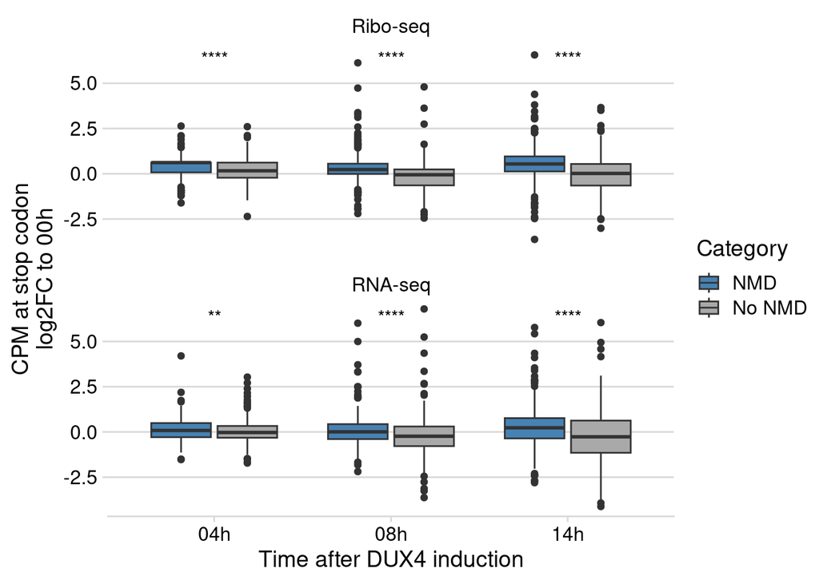

```r
rna_plot_df$seqtype="RNA-seq"
ribo_plot_df$seqtype="Ribo-seq"

df_cpm_log2fc<-rbind(rna_plot_df,ribo_plot_df)
save(df_cpm_log2fc, file="df_cpm_log2fc.RData")
ggplot(df_cpm_log2fc, aes(x=time, y=log2FCs, fill=type)) +
  geom_boxplot() + theme_minimal_hgrid() + scale_fill_manual(values = c("steelblue","dark grey")) +
  labs(x="Time after DUX4 induction", y="CPM at stop codon\nlog2FC to 00h", fill="Category") +
  stat_compare_means(aes(label = after_stat(p.signif)), method = "wilcox.test",paired = T, method.args = list(alternative = "less"),label.y = 6 )+
  facet_wrap(~seqtype,nrow = 2)
```